# Solutions — Session 5: Text Mining a Focus-Group Transcript

M731 · Full worked walkthrough (companion to session-05.qmd)

Author

Shay Abbasi

## Purpose

Session 5 is mostly a concept-and-workshop session (qualitative methods, a discussion-guide workshop) rather than a coded analysis, so this solutions file is shorter than most. It expands the deck’s small R text-mining demo and adds a short note on what such a demo can and cannot substitute for.

**Dataset.** `maritime_focus.txt` contains four instructor-simulated focus-group transcripts on Maritime Roast subscriber churn (lapsed subscribers in Halifax and Moncton, current subscribers considering downgrading, and Ontario prospects). These are illustrative, not real fieldwork.

## Setup

```r
library(tidyverse)
library(readtext)
library(tidytext)

transcripts <- readtext("data/maritime_focus.txt")
```

## Word frequencies

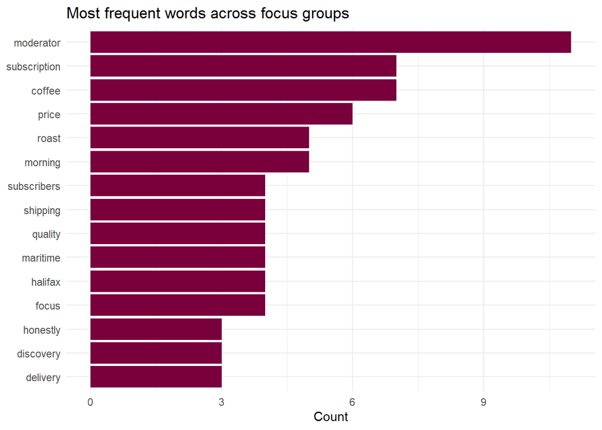

Figure 1: Most frequent content words across the four transcripts

```r
tokens <- transcripts |>
  unnest_tokens(word, text) |>
  anti_join(stop_words, by = "word") |>
  filter(!word %in% c("p1","p2","p3","p4","p5","p6","p7","p8",
                       "p9","p10","p11","p12","p13","p14","p15","p16")) |>
  count(word, sort = TRUE)

tokens |>
  slice_head(n = 15) |>
  ggplot(aes(x = fct_reorder(word, n), y = n)) +
  geom_col(fill = "#7A003C") +
  coord_flip() +
  labs(title = "Most frequent words across focus groups", x = NULL, y = "Count") +
  theme_minimal()
```

**Interpretation.** Words like “subscription,” “price,” “shipping,” and “coffee” dominate — consistent with the churn themes participants raised: price increases, delivery reliability, and the coffee ritual itself. This is a useful **first pass**, not a finding — it tells you what to look for when you actually code the transcripts, not what the transcripts mean.

## A simple bigram pass (what pairs of words co-occur?)

```r
bigrams <- transcripts |>
  unnest_tokens(bigram, text, token = "ngrams", n = 2) |>
  separate(bigram, into = c("w1", "w2"), sep = " ") |>
  filter(!w1 %in% stop_words$word, !w2 %in% stop_words$word) |>
  count(w1, w2, sort = TRUE) |>
  slice_head(n = 10)

bigrams
```

```
         w1          w2 n
1  maritime       roast 4
2         8   moderator 2
3    lapsed subscribers 2
4   morning     routine 2
5     price sensitivity 2
6     roast         p10 2
7         1      lapsed 1
8         2      lapsed 1
9         3     current 1
10        4       mixed 1
```

## What this demo does and doesn’t replace

- **Does:** give you a fast, rough sense of vocabulary and salient topics before you start coding by hand; useful for triaging which transcripts to prioritise in a large corpus.
- **Doesn’t:** replace systematic coding. It can’t tell you *why* someone mentioned price, whether the mention was positive or negative, or which theme a given quote supports. Word counts flatten context — “I didn’t mind the price increase” and “the price increase is why I left” count identically here.

For a real project, use this kind of pass as a **starting map**, then code manually (or with CAQDAS software) for anything you intend to report as a finding.

## Take-away for students

Qualitative rigour comes from systematic coding and inference, not from a word cloud. Use text mining to orient yourself in a large corpus quickly — never as a substitute for reading and coding the material.